# Seminarski rad

Gala Posedi 64/2021

## Prvi zadatak

```r
#install.packages("readODS")
library(readODS)
library(caret)
```

```r
library(ggplot2)
library(dplyr)
library(mice)
library(Matrix)
rakete = read_ods("C:\\Fakultet\\Cetvrta godina\\SS3\\rakete.ods")
attach(rakete)
head(rakete)
```

```
## # A tibble: 6 × 12
##   rusko_ime       NATO_ime   masa_kg duzina_m kalibar_m broj_podglava payload_kg
##   <chr>           <chr>        <dbl>    <dbl>     <dbl>         <dbl>      <dbl>
## 1 R-36M2 Voevoda  SS-18 Sat…  209600     32.2      3.05            10       8800
## 2 UR-100N         SS-19 Sti…  105600     27        2.5              6       3355
## 3 RT-2PM Topol    SS-25 Sic…   45100     21.5      1.8              1       1000
## 4 RT-2PM2 Topol-M SS-27 Mod…   47200     22.7      1.9              1       1200
## 5 RS-24 Yars      SS-27 Mod…   49600     23        2                3       1200
## 6 R-29R Vysota    SS-N-18 S…   35300     14.4      1.8              3       1650
## # ℹ 5 more variables: tip_goriva <chr>, max_domet_km <dbl>,
## #   nacin_lansiranja <chr>, broj_faza_motora <dbl>, klasa_po_dometu <chr>
```

## Drugi zadatak

NA vrednosti su popunjene ugrađenom funkcijom u R-u MICE. Inicijalno su se NA vrednosti popunjavale funkcijom PREDICT, ali to nije davalo zadovoljavajuće rezultate jer se NA vrednosti pojavljuju u više kolona.

Funkcija MICE radi po principu procenjivanja NA vrednostu na osnovu ostalih podataka.

```r
rakete[31, ]
```

```
## # A tibble: 1 × 12
##   rusko_ime    NATO_ime masa_kg duzina_m kalibar_m broj_podglava payload_kg
##   <chr>        <chr>      <dbl>    <dbl>     <dbl>         <dbl>      <dbl>
## 1 Dong Feng 16 CSS-11        NA       NA       1.2             3       1500
## # ℹ 5 more variables: tip_goriva <chr>, max_domet_km <dbl>,
## #   nacin_lansiranja <chr>, broj_faza_motora <dbl>, klasa_po_dometu <chr>
```

Da bismo implementirali tu funkciju, prvo moramo kategoričke promenljive pretvoriti u numeričke.

```r
tip_goriva
```

```
##  [1] "Tecno"  "Tecno"  "Cvrsto" "Cvrsto" "Cvrsto" "Tecno"  "Tecno"  "Tecno"
##  [9] "Tecno"  "Tecno"  "Cvrsto" "Tecno"  "Cvrsto" "Cvrsto" "Cvrsto" "Cvrsto"
## [17] "Cvrsto" "Cvrsto" "Tecno"  "Cvrsto" "Cvrsto" "Cvrsto" "Tecno"  "Tecno"
## [25] "Tecno"  "Tecno"  "Cvrsto" "Cvrsto" "Cvrsto" "Cvrsto" "Cvrsto" "Cvrsto"
## [33] "Cvrsto" "Cvrsto" "Tecno"  "Cvrsto" "Tecno"  "Cvrsto" "Cvrsto"
```

```r
tip_goriva = factor(tip_goriva, levels = c("Tecno", "Cvrsto"), labels = c(0,1))
nacin_lansiranja =  factor(nacin_lansiranja, levels = c("Silos", "RM TEL", "Mornaricki", "Avion"), labels = c(1,2,3,4))
klasa_po_dometu =  factor(klasa_po_dometu, levels = c("L", "S", "M"), labels = c(1,2,3))
rakete$tip_goriva = tip_goriva
rakete$nacin_lansiranja = nacin_lansiranja
rakete$klasa_po_dometu = klasa_po_dometu
tip_goriva
```

```
##  [1] 0 0 1 1 1 0 0 0 0 0 1 0 1 1 1 1 1 1 0 1 1 1 0 0 0 0 1 1 1 1 1 1 1 1 0 1 0 1
## [39] 1
## Levels: 0 1
```

Algoritam funkcije MICE je sledeći:

1. Inicijalizuje NA vrednosti (uglavnom srednja vrednost);
2. Za svaku promenljivu koja sadrži nedostajuće vrednosti stvara model predikcije koristeći kao prediktore preostale promenljive;
3. Pomoću modela predviđa i menja NA vrednosti;
4. Ponavlja ovaj proces sa svim promenljivima koje sadrže NA više puta (argument maxit);
5. Generiše različite datasetove (argument m).

Pmm (predictive mean matching) je metod koji se koristi u popunjavanju NA vrednosti.

```r
#install.packages("mice")
library(mice)


umetanje_MICE = mice(rakete, m = 5, method = 'pmm', maxit = 6, seed = 70)
summary(umetanje_MICE)
```

```
## Class: mids
## Number of multiple imputations:  5
## Imputation methods:
##        rusko_ime         NATO_ime          masa_kg         duzina_m
##               ""               ""            "pmm"            "pmm"
##        kalibar_m    broj_podglava       payload_kg       tip_goriva
##               ""            "pmm"               ""               ""
##     max_domet_km nacin_lansiranja broj_faza_motora  klasa_po_dometu
##               ""               ""               ""               ""
## PredictorMatrix:
##               rusko_ime NATO_ime masa_kg duzina_m kalibar_m broj_podglava
## rusko_ime             0        0       1        1         1             1
## NATO_ime              0        0       1        1         1             1
## masa_kg               0        0       0        1         1             1
## duzina_m              0        0       1        0         1             1
## kalibar_m             0        0       1        1         0             1
## broj_podglava         0        0       1        1         1             0
##               payload_kg tip_goriva max_domet_km nacin_lansiranja
## rusko_ime              1          1            1                1
## NATO_ime               1          1            1                1
## masa_kg                1          1            1                1
## duzina_m               1          1            1                1
## kalibar_m              1          1            1                1
## broj_podglava          1          1            1                1
##               broj_faza_motora klasa_po_dometu
## rusko_ime                    1               1
## NATO_ime                     1               1
## masa_kg                      1               1
## duzina_m                     1               1
## kalibar_m                    1               1
## broj_podglava                1               1
## Number of logged events:  2
##   it im dep     meth       out
## 1  0  0     constant rusko_ime
## 2  0  0     constant  NATO_ime
```

```r
rakete_umetanje = complete(umetanje_MICE, 3) #broj 3 oznacava da biramo trecu imputaciju

rakete = rakete_umetanje

rakete[31, ]
```

```
##       rusko_ime NATO_ime masa_kg duzina_m kalibar_m broj_podglava payload_kg
## 31 Dong Feng 16   CSS-11    4020    10.25       1.2             3       1500
##    tip_goriva max_domet_km nacin_lansiranja broj_faza_motora klasa_po_dometu
## 31          1         1000                2                1               3
```

Ovde je korisćena MICE funkcija jer se činilo najsmislenijim uzeti već ugrađenu, efikasnu funkciju koja se može uspešno implementirati iako se NA podaci nalaze kod većeg broja prediktora.

## Treći zadatak

Za početak, izbacićemo kategoričke promenljive koje se ne mogu numerizovati.

```r
rakete2 = rakete %>% dplyr::select(-rusko_ime, -NATO_ime)
```

Potom se gleda koji prediktori su numerički, pošto se samo oni standardizuju.

```r
numericke_kolone = sapply(rakete2, is.numeric)
numericke_kolone
```

```
##          masa_kg         duzina_m        kalibar_m    broj_podglava
##             TRUE             TRUE             TRUE             TRUE
##       payload_kg       tip_goriva     max_domet_km nacin_lansiranja
##             TRUE            FALSE             TRUE            FALSE
## broj_faza_motora  klasa_po_dometu
##             TRUE            FALSE
```

Na kraju, standardizuju se numerički prediktori, dok se faktori ne diraju.

```r
rakete2_standardizovano = rakete2
rakete2_standardizovano[numericke_kolone] = scale(rakete2[numericke_kolone])
rakete2 = rakete2_standardizovano

head(rakete2)
```

```
##       masa_kg    duzina_m kalibar_m broj_podglava  payload_kg tip_goriva
## 1  3.19181172  2.23510842 2.0859515     1.5471016  3.49272893          0
## 2  1.24349083  1.57790469 1.3247589     0.5579711  0.80484111          0
## 3  0.11009262  0.88278535 0.3559684    -0.6784421 -0.35768888          1
## 4  0.14943371  1.03444775 0.4943671    -0.6784421 -0.25896022          1
## 5  0.19439497  1.07236335 0.6327657    -0.1838768 -0.25896022          1
## 6 -0.07349916 -0.01455052 0.3559684    -0.1838768 -0.03682073          0
##   max_domet_km nacin_lansiranja broj_faza_motora klasa_po_dometu
## 1    2.0273365                1       0.09164958               1
## 2    0.8804534                1       0.09164958               1
## 3    1.0716006                2       1.28309418               1
## 4    1.0716006                2       1.28309418               1
## 5    1.2627478                2       1.28309418               1
## 6    0.2114382                3       0.09164958               1
```

Dele se podaci na trening i test skup radi pripreme za modelovanje.

```r
set.seed(70)
trening_indeksi = createDataPartition(rakete2_standardizovano$max_domet_km, p = 0.7, list = FALSE)
trening_skup = rakete2[trening_indeksi, ]
test_skup = rakete2[-trening_indeksi, ]
```

Koristiće se dva tipa modelovanja: RandomForest i linearna regresija pa ćemo uporediti performanse ovih modela.

### RandomForest model

Prvo se vrši numerizacija faktora da bi se RandomForest mogao uspešno implementirati.

```r
library(glmnet)
tip_goriva = as.numeric(tip_goriva)
nacin_lansiranja = as.numeric(nacin_lansiranja)
klasa_po_dometu = as.numeric(klasa_po_dometu)

tip_goriva
```

```
##  [1] 1 1 2 2 2 1 1 1 1 1 2 1 2 2 2 2 2 2 1 2 2 2 1 1 1 1 2 2 2 2 2 2 2 2 1 2 1 2
## [39] 2
```

Implementacija randomForest modela:

```r
library(randomForest)
rf_model = randomForest(max_domet_km ~ ., data = trening_skup, ntree = 500, mtry = 3)
print(rf_model)
```

```
##
## Call:
##  randomForest(formula = max_domet_km ~ ., data = trening_skup,      ntree = 500, mtry = 3)
##                Type of random forest: regression
##                      Number of trees: 500
## No. of variables tried at each split: 3
##
##           Mean of squared residuals: 0.07991317
##                     % Var explained: 90.77
```

```r
predikcije = predict(rf_model, newdata = test_skup)
predikcije
```

```
##          2          9         12         14         19         24         29
##  1.2575079  0.6758354  1.4981431 -0.7771347 -0.6751989 -0.8890219 -0.9412729
##         32         33         37         38
## -0.6263224 -0.3112191  0.9897805  1.1230052
```

```r
zavisna_promenljiva_test = test_skup$max_domet_km
zavisna_promenljiva_test
```

```
##  [1]  0.88045337  0.55550314  2.40963090 -0.97367438 -0.41934753 -0.97367438
##  [7] -0.95073672 -0.62005208 -0.26642978 -0.08483995  1.83618933
```

#### Vizualizacija modela

Sada ćemo upotrebom grafika da vidimo vizuelno performanse našeg modela.

##### Vip funkcija

Prvo se koristi funckija vip koja barplot-om prikazuje uticaj, odnosno korelisanost prediktora u našem modelu.

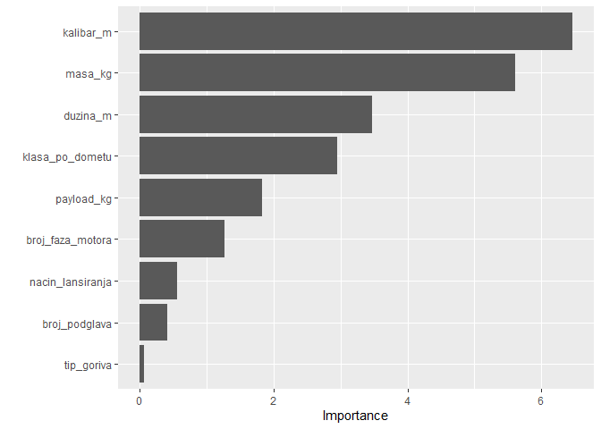

```r
#install.packages("vip")
library(vip)
vip(rf_model, nm_features = 10, col = "red")
```

##### Plot stvarnih vrednosti vs predikcija

Implementiranjem funkcije plot možemo videti odnos stvarnih vrednosti i predikcija koji grafički pokazuje koliko efikasno nas model procenjuje traženi prediktor

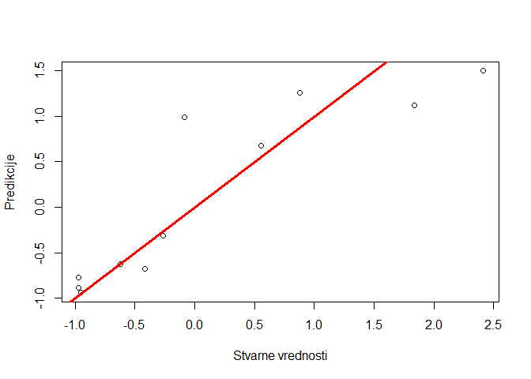

```r
plot(zavisna_promenljiva_test, predikcije, xlab = "Stvarne vrednosti", ylab = "Predikcije")
abline(0, 1, col = "red", lwd = 3)
```

Model solidno procenjuje stvarne vrednosti, ali ne najbolje. S obzirom da je varijansa objašnjena modelom skoro 91%, očekivali bismo da predikcije budu dosta preciznije i bliže stvarnim vrednostima. To može biti zbog toga što prediktor “max_domet” ima dosta autlajera koji ne utiču mnogo na ukupnu varijansu ali se zato njihovo postojanje vidi u ovom plotu.

#### Evaluacija modela korišćenjem MSE i R2

Računanjem MSE i koeficijenta determinacije se mogu numerički videti performanse modela.

```r
mse = mean((zavisna_promenljiva_test - predikcije)^2)
R_2 = 1 - sum((predikcije - zavisna_promenljiva_test)^2) / sum((zavisna_promenljiva_test - mean(zavisna_promenljiva_test))^2)

mse
```

```
## [1] 0.251299
```

```r
R_2
```

```
## [1] 0.7955977
```

Priložena vrednost koeficijenta determinacije ukazuje na to da naš model ima solidnu prediktivnu moć. Iako su R2 i “var explained” u RandomForest modelu ekvivalentne stvari, uglavnom nemaju istu vrednost jer se računaju na različitim skupovima. “Out of bag” trening skup se koristi u RandomForest modelovanju, dok se za računanje vrednosti R2 koristi na nezavisnom test skupu pa se zato te dve vrednosti razlikuju.

Vrednost MSE, koja je približno 0.25, nam pokazuje da su greške u proseku manje od 0.5 standardne devijacije. To nam ukazuje da je model solidno precizan jer greši manje od očekivane varijacije u podacima (koja je 1 zbog standardizacije).

Prethodne priložene performanse pokazuju da je naš model solidan, ali ne najbolji, pa se zato implementira i sledeći.

### Linearna regresija

Sada će se implementacijom linearne regresije predviđati vrednosti traženog parametra “max_domet”.

```r
summary(lm(max_domet_km~., data = rakete2_standardizovano))
```

```
##
## Call:
## lm(formula = max_domet_km ~ ., data = rakete2_standardizovano)
##
## Residuals:
##      Min       1Q   Median       3Q      Max
## -0.34944 -0.10516 -0.02512  0.06049  0.42867
##
## Coefficients:
##                   Estimate Std. Error t value Pr(>|t|)
## (Intercept)       -0.79303    0.30714  -2.582 0.015810 *
## masa_kg            0.16224    0.21763   0.746 0.462654
## duzina_m           0.44560    0.16181   2.754 0.010605 *
## kalibar_m          0.31154    0.16199   1.923 0.065474 .
## broj_podglava     -0.02785    0.07240  -0.385 0.703662
## payload_kg         0.20792    0.10994   1.891 0.069788 .
## tip_goriva1        0.15594    0.11718   1.331 0.194802
## nacin_lansiranja2  1.10798    0.27727   3.996 0.000472 ***
## nacin_lansiranja3  1.05839    0.31788   3.330 0.002608 **
## nacin_lansiranja4  1.45314    0.37782   3.846 0.000697 ***
## broj_faza_motora   0.07279    0.08139   0.894 0.379363
## klasa_po_dometu2  -0.42570    0.21706  -1.961 0.060651 .
## klasa_po_dometu3  -0.56025    0.15462  -3.623 0.001238 **
## ---
## Signif. codes:  0 '***' 0.001 '**' 0.01 '*' 0.05 '.' 0.1 ' ' 1
##
## Residual standard error: 0.2017 on 26 degrees of freedom
## Multiple R-squared:  0.9722, Adjusted R-squared:  0.9593
## F-statistic: 75.68 on 12 and 26 DF,  p-value: < 2.2e-16
```

Neće se uzeti svi prediktori u razmatranje, već samo oni koji intuitivno deluju logično ali i oni čija je p-vrednost mala

```r
l_model = lm(max_domet_km ~ duzina_m +nacin_lansiranja + klasa_po_dometu + broj_podglava, data = trening_skup)
summary(l_model)
```

```
##
## Call:
## lm(formula = max_domet_km ~ duzina_m + nacin_lansiranja + klasa_po_dometu +
##     broj_podglava, data = trening_skup)
##
## Residuals:
##      Min       1Q   Median       3Q      Max
## -0.36077 -0.14274 -0.00305  0.10826  0.60665
##
## Coefficients:
##                   Estimate Std. Error t value Pr(>|t|)
## (Intercept)        0.11163    0.40360   0.277 0.784936
## duzina_m           0.62122    0.14269   4.354 0.000308 ***
## nacin_lansiranja2  0.51503    0.37642   1.368 0.186416
## nacin_lansiranja3  0.27563    0.40488   0.681 0.503829
## nacin_lansiranja4  0.92853    0.51435   1.805 0.086115 .
## klasa_po_dometu2  -0.92193    0.22925  -4.022 0.000669 ***
## klasa_po_dometu3  -1.07878    0.18795  -5.740 1.29e-05 ***
## broj_podglava      0.14530    0.08533   1.703 0.104093
## ---
## Signif. codes:  0 '***' 0.001 '**' 0.01 '*' 0.05 '.' 0.1 ' ' 1
##
## Residual standard error: 0.2444 on 20 degrees of freedom
## Multiple R-squared:  0.9507, Adjusted R-squared:  0.9334
## F-statistic: 55.07 on 7 and 20 DF,  p-value: 1.077e-11
```

```r
predikcija_l_model = predict(l_model, newdata = test_skup)
predikcija_l_model
```

```
##            2            9           12           14           19           24
##  1.172924851  0.634422196  2.199588970 -1.286096209 -1.172078585 -0.650205554
##           29           32           33           37           38
## -0.960330385 -0.670584948 -0.591146761 -0.007000591  1.439114975
```

#### Vizualizacija modela - Plot stvarnih vrednosti vs predikcija

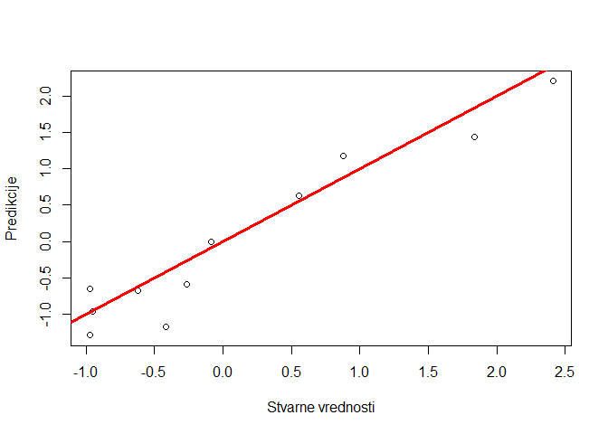

```r
plot(zavisna_promenljiva_test, predikcija_l_model, xlab = "Stvarne vrednosti", ylab = "Predikcije")
abline(0, 1, col = "red", lwd = 3)
```

Upoređuju se prethodna dva plot-a predikcija u odnosu na stvarne vrednosti prediktora.

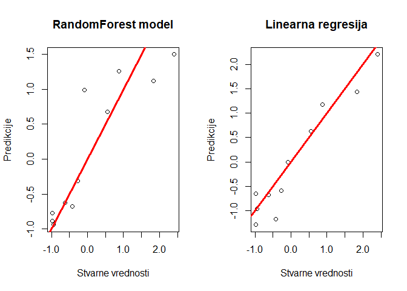

```r
par(mfrow = c(1, 2))
plot(zavisna_promenljiva_test, predikcije, xlab = "Stvarne vrednosti", ylab = "Predikcije", main = "RandomForest model")
abline(0, 1, col = "red",lwd = 3)
plot(zavisna_promenljiva_test, predikcija_l_model, xlab = "Stvarne vrednosti", ylab = "Predikcije", main = "Linearna regresija")
abline(0, 1, col = "red", lwd = 3)
```

Vidi se da ovaj model mnogo bolje prediktuje stvarne vrednosti od prethodnog.

#### Evaluacija modela korišćenjem MSE i R2

Analogno, računa se MSE i koeficijent determinacije

```r
mse_l_model = mean((zavisna_promenljiva_test - predikcija_l_model)^2)
R_2_l_model = 1 - sum((predikcija_l_model - zavisna_promenljiva_test)^2) / sum((zavisna_promenljiva_test - mean(zavisna_promenljiva_test))^2)

mse_l_model
```

```
## [1] 0.1069584
```

```r
R_2_l_model
```

```
## [1] 0.9130019
```

MSE je zadovoljavajuće mali, a R2 je značajno veliki. Možemo na osnovu prethodnih performansi zaključiti da ovaj model uspešno i efikasno predviđa traženi prediktor.

```r
if(mse > mse_l_model){
  cat("Manja MSE je kod linearne regresije i iznosi: ", mse_l_model, "\n")
}else{
  cat("Manja MSE je kod random Forest modela i iznosi: ", mse, "\n")

}
```

```
## Manja MSE je kod linearne regresije i iznosi:  0.1069584
```

```r
if(R_2 > R_2_l_model){
  cat("Vece R^2 je kod randomForest modela i iznosi: ", R_2, "\n")
}else{
  cat("Vece R^2 je kod linearne regresije i iznosi: ", R_2_l_model, "\n")
}
```

```
## Vece R^2 je kod linearne regresije i iznosi:  0.9130019
```

Kako su i MSE i R2 bolje u linearnom modelu, može se reći da je ovaj model i bolji od prethodnog RandomForest modela.

## Četvrti zadatak

Promenljive RM TEL, avion i mornarički imaju pokretan lanser dok Silosi imaju fiksan lanser.

Pravi se funkcija koja menja promenljivu “nacin_lansiranja” tako što joj dodeljuje 0 ukoliko je lanser fiksan, u suprotnom dodeljuje 1.

```r
tip_lansiranja = sapply(rakete2$nacin_lansiranja, function(i){if(nacin_lansiranja[i] == 1){
  nacin_lansiranja[i] = 0
}else{
  nacin_lansiranja[i] = 1
}})

nacin_lansiranja = tip_lansiranja
rakete2$nacin_lansiranja = nacin_lansiranja
```

Klasifikator će se implemenirati korišćenjem logističke regresije posto je obelezje tip_lansiranja, odnosno način lansiranja, binarno.

Odvajamo podatke prvo na trening skup i validacioni skup.

```r
set.seed(70)
trening_val_indeks = createDataPartition(rakete2$nacin_lansiranja, p = 0.7, list = FALSE)
trening_val_skup = rakete2[trening_val_indeks,]
test_skup = rakete2[-trening_val_indeks,]

logisticka_regresija = glm(nacin_lansiranja~., data = trening_val_skup, family = binomial)
summary(logisticka_regresija)
```

```
##
## Call:
## glm(formula = nacin_lansiranja ~ ., family = binomial, data = trening_val_skup)
##
## Deviance Residuals:
##        Min          1Q      Median          3Q         Max
## -1.326e-05  -2.961e-07  -2.110e-08  -2.110e-08   1.440e-05
##
## Coefficients:
##                    Estimate Std. Error z value Pr(>|z|)
## (Intercept)       6.136e+01  8.800e+05       0        1
## masa_kg          -4.751e+00  2.690e+06       0        1
## duzina_m         -1.005e+02  3.602e+06       0        1
## kalibar_m        -1.148e+02  1.590e+06       0        1
## broj_podglava    -8.626e+00  2.875e+05       0        1
## payload_kg        9.061e+01  1.043e+06       0        1
## tip_goriva1      -7.715e+01  1.436e+06       0        1
## max_domet_km      1.724e+01  8.389e+05       0        1
## broj_faza_motora  3.259e+01  1.966e+05       0        1
## klasa_po_dometu2 -1.653e+02  2.908e+06       0        1
## klasa_po_dometu3 -1.431e+02  3.652e+06       0        1
##
## (Dispersion parameter for binomial family taken to be 1)
##
##     Null deviance: 2.9096e+01  on 27  degrees of freedom
## Residual deviance: 1.3821e-09  on 17  degrees of freedom
## AIC: 22
##
## Number of Fisher Scoring iterations: 25
```

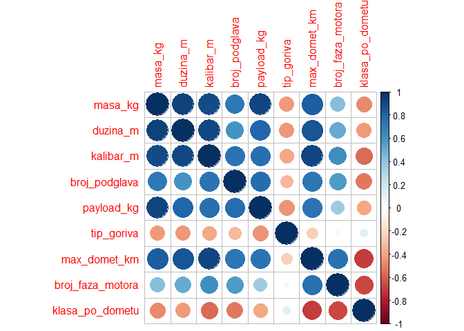

```r
#install.packages("corrplot")
library(corrplot)
rakete2_numericki = sapply(rakete2, as.numeric)

corrplot(cor(rakete2_numericki[ ,-8]))
```

Sa ovog grafika se može zaključiti i da su podaci znatno korelisani, što takođe može rezultovati pojavu overfitting-a.

Rešićemo to Ridge, tj L2 regularizacijom koja je posebno efikasna ukoliko radimo sa korelisanim podacima.

### L2 regularizacija (Ridge regresija)

```r
svi_prediktori_val = trening_val_skup[ ,-8]
zavisna_promenljiva_val = trening_val_skup$nacin_lansiranja


svi_prediktori_test = test_skup[ ,-8]
zavisna_promenljiva_test = test_skup$nacin_lansiranja

ridge_model = glmnet(svi_prediktori_val,zavisna_promenljiva_val,lambda = 14,family = 'binomial', alpha = 0)
ridge_model
```

```
##
## Call:  glmnet(x = svi_prediktori_val, y = zavisna_promenljiva_val, family = "binomial",      alpha = 0, lambda = 14)
##
##   Df %Dev Lambda
## 1  9 0.76     14
```

```r
ridge_model$beta
```

```
## 9 x 1 sparse Matrix of class "dgCMatrix"
##                             s0
## masa_kg          -0.0027921933
## duzina_m         -0.0041548474
## kalibar_m         0.0012130979
## broj_podglava     0.0049183094
## payload_kg       -0.0007022442
## tip_goriva       -0.0146747592
## max_domet_km      0.0018407577
## broj_faza_motora  0.0082897201
## klasa_po_dometu  -0.0129812765
```

Sada ćemo implementirati opet Ridge model ali tako da argument lambda nije fiksiran jednom vrednošću, već predstavlja vektor.

```r
ridge_model_2 = glmnet(svi_prediktori_val,zavisna_promenljiva_val,lambda = c(0.014, 0.14, 14, 140, 1400,14000),family = 'binomial', alpha = 0)
```

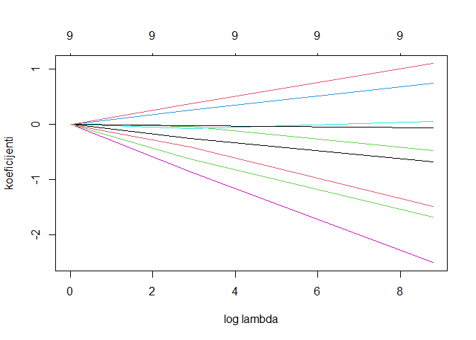

```r
plot(ridge_model_2, xlab = "log lambda", ylab = "koeficijenti")
```

Poučeni ovih prethodnim plotom, zaključujemo da je treba optimizovati lambdu da bi naš model bio najefikasniji mogući. To će se raditi putem kros-validacije.

### Kros validacija

```r
svi_prediktori_val = trening_val_skup[ ,-8]
zavisna_promenljiva_val = trening_val_skup$nacin_lansiranja


svi_prediktori_test = test_skup[ ,-8]
zavisna_promenljiva_test = test_skup$nacin_lansiranja
```

Nakon ovoga, pravimo opseg za lambda i tražimo najoptimalniju vrednost.

```r
lambde = 10^seq(2,-2, by = -0.001)

svi_prediktori_val = as.matrix(sapply(svi_prediktori_val, function(x) as.numeric(as.character(x))))

ridge_model_regularizacija_cv = cv.glmnet(as.matrix(svi_prediktori_val), as.matrix(zavisna_promenljiva_val), nfolds = 10, lambda = lambde, alpha = 0, family = 'binomial', type.measure = "class",standardize = F)
```

[output not shown]

```r
podaci_val = data.frame(svi_prediktori_val, zavisna_promenljiva_val)
podaci_val$zavisna_promenljiva_val = as.factor(podaci_val$zavisna_promenljiva_val)
table(podaci_val$zavisna_promenljiva_val)
```

```
##
##  0  1
## 22  6
```

Koristiće se tehnika undersampling-a većinske klase.

### Undersampling

```r
balansirani_podaci = downSample(x = podaci_val[, -ncol(podaci_val)],y = podaci_val$zavisna_promenljiva_val)

table(balansirani_podaci$Class)
```

```
##
## 0 1
## 6 6
```

Tabelarno je prikazano da su podaci izbalansirani.

Nakon primene undersampling-a, opet se primenjuje L2 regularizacija.

#### Misclassification Error

```r
svi_prediktori_balansirano = balansirani_podaci[, -ncol(balansirani_podaci)]
zavisna_promenljiva_balansirano = balansirani_podaci[, ncol(balansirani_podaci)]

ridge_model_regularizacija_cv = cv.glmnet(as.matrix(svi_prediktori_balansirano),as.matrix(zavisna_promenljiva_balansirano),nfolds = 10,lambda = lambde,alpha = 0,family = 'binomial',type.measure = "class",standardize = FALSE)
```

[output not shown]

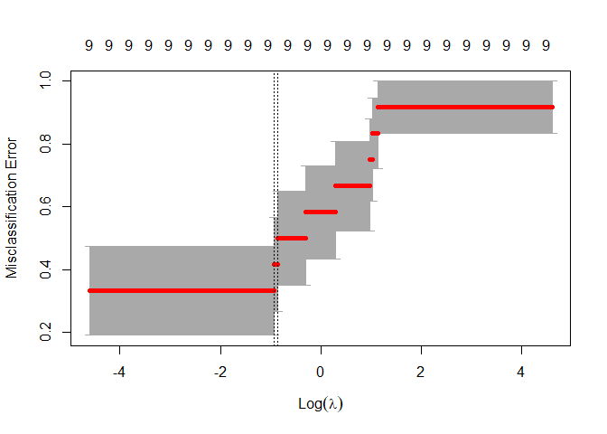

```r
plot(ridge_model_regularizacija_cv)
```

Ovaj grafik pokazuje kros-validacionu klasifikacionu grešku u zavisnosti od različitih vrednosti za log(lambda).

Klasifikaciona greška meri procenat pogrešnih klasifikacija koje je model pokazao. Drugim rečima: Misclassification Error = (Broj pogrešnih predikcija)/(Ukupan broj predikcija).

Cilj je vizuelno uvideti koje lambda minimizuje ovu grešku.

Sive zone predstavljaju standardnu grešku oko srednje vrednosti klasifikacione greške za svako lambda. Drugim rečima: siva zona = prosečna greška +- standardna greška.

Dve vertiklane isprekidane linije predstavljaju dve vrednosti za lambda: lambda.min i lambda.1se

Lambda.1se predstavlja najveće lambda čija je greška još unutar sive zone minimuma.

Izabraćemo ipak za najbolje lambda minimum.

```r
najbolji_lambda = ridge_model_regularizacija_cv$lambda.min
najbolji_lambda
```

```
## [1] 0.3944573
```

```r
najbolji_ridge_model_regularizacija = glmnet(svi_prediktori_balansirano, zavisna_promenljiva_balansirano, family = 'binomial', lambda = najbolji_lambda, alpha = 0, standardize = F)
```

Pogledajmo kako će sada model predvideti vrednosti i procenimo njegove performanse.

#### Predikcije vrednosti prediktora “nacin_lansiranja”

```r
svi_prediktori_test = as.matrix(sapply(svi_prediktori_test, function(x) as.numeric(as.character(x))))

predikcija_na_test_skupu = predict(najbolji_ridge_model_regularizacija, newx = svi_prediktori_test)
predikcija_zavisne_prom = predict(najbolji_ridge_model_regularizacija, s = najbolji_lambda, newx = svi_prediktori_test, type = 'class')
```

### Performanse modela

Sada će se implementacijom alata poput ROC, AUC, matrice konfuzije, F1 score proceniti performanse ovog modela

##### ROC kriva i AUC

```r
verovatnoce = predict(najbolji_ridge_model_regularizacija,
                      s = najbolji_lambda,
                      newx = svi_prediktori_test,
                      type = "response")

library(pROC)
roc_kriva = roc(zavisna_promenljiva_test, as.numeric(verovatnoce))
auc(roc_kriva)
```

```
## Area under the curve: 0.6
```

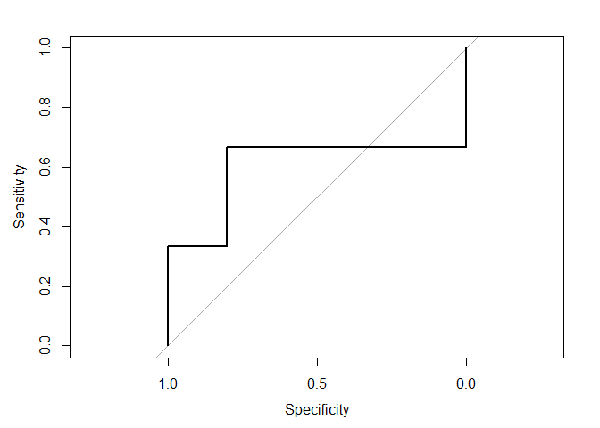

```r
plot(roc_kriva)
```

AUC je izmedju 0.6 i 0.7, to može dosta bolje ali s obzirom da smo vršili regularizaciju nad malim obimom uzorka, gde su se prediktori penalili više nego što je trebalo, ovaj rezultat je zadovoljavajući.

##### Matrica konfuzije, Accuracy i F1 Score

```r
matrica_konfuzije_1 = confusionMatrix(as.factor(predikcija_zavisne_prom), as.factor(zavisna_promenljiva_test))
matrica_konfuzije_1
```

```
## Confusion Matrix and Statistics
##
##           Reference
## Prediction 0 1
##          0 4 2
##          1 1 4
##
##                Accuracy : 0.7273
##                  95% CI : (0.3903, 0.9398)
##     No Information Rate : 0.5455
##     P-Value [Acc > NIR] : 0.1829
##
##                   Kappa : 0.459
##
##  Mcnemar's Test P-Value : 1.0000
##
##             Sensitivity : 0.8000
##             Specificity : 0.6667
##          Pos Pred Value : 0.6667
##          Neg Pred Value : 0.8000
##              Prevalence : 0.4545
##          Detection Rate : 0.3636
##    Detection Prevalence : 0.5455
##       Balanced Accuracy : 0.7333
##
##        'Positive' Class : 0
##
```

```r
TN = 4
TP = 4
FN = 1
FP = 2
```

Iz matrice konfuzije se vidi koliki je Accuracy, ali se može i ručno izračunati:

```r
tacnost = (TN+TP)/(TN+TP+FP+FN)
tacnost
```

```
## [1] 0.7272727
```

```r
recall = TP/(TP+FN)
recall
```

```
## [1] 0.8
```

```r
preciznost = TP/(TP+FP)

F1 = 2*preciznost*recall/(preciznost+recall)
F1
```

```
## [1] 0.7272727
```

Iz priloženog se može zaključiti da su Accuracy i F1 Score sasvim solidni, tako da je regularizovani izbalansirani model efikasan.

#### Poređenje metrika evaluacije sa početnim modelom

```r
predikcija_pre_regularizacije = predict(logisticka_regresija, newdata = test_skup, type = 'response')
predikcija_zavisne_prom_pre = as.numeric(predikcija_pre_regularizacije > 0.5)

matrica_konfuzije_2 = confusionMatrix(as.factor(predikcija_zavisne_prom_pre), as.factor(zavisna_promenljiva_test))
matrica_konfuzije_2
```

```
## Confusion Matrix and Statistics
##
##           Reference
## Prediction 0 1
##          0 5 4
##          1 0 2
##
##                Accuracy : 0.6364
##                  95% CI : (0.3079, 0.8907)
##     No Information Rate : 0.5455
##     P-Value [Acc > NIR] : 0.3853
##
##                   Kappa : 0.3125
##
##  Mcnemar's Test P-Value : 0.1336
##
##             Sensitivity : 1.0000
##             Specificity : 0.3333
##          Pos Pred Value : 0.5556
##          Neg Pred Value : 1.0000
##              Prevalence : 0.4545
##          Detection Rate : 0.4545
##    Detection Prevalence : 0.8182
##       Balanced Accuracy : 0.6667
##
##        'Positive' Class : 0
##
```

```r
TN = 5
TP = 2
FN = 0
FP = 4
```

Vidi se da je ovde FN =0, što dovodi do toga da Sensitivity = 1. To znači da naš početni model nije u stanju da prepozna FALSE NEGATIVE vrednosti, a to je jos jedan pokazatelj da može doći do preprilagodjavanja.

```r
tacnost = (TN+TP)/(TN+TP+FP+FN)
tacnost
```

```
## [1] 0.6363636
```

```r
recall = TP/(TP+FN)
recall
```

```
## [1] 1
```

Recall je 1, zbog toga što je FN = 0 što jeste velika vrednost, ali je takođe nepoželjno u praksi jer pokazuje da model nije realističan u predviđanju.

```r
preciznost = TP/(TP+FP)

F1 = 2*preciznost*recall/(preciznost+recall)
F1
```

```
## [1] 0.5
```

Upoređujući metrike evaluacije ova dva modela, možemo zaključiti da je balansirani regularizovani model efikasniji i optimalniji.

## Peti zadatak

Rakete sa srednjim dometom su one koje su kod prediktora “klasa_po_dometu” označene kao “M” - medium range. Nakon faktorizacije, postale su one koje su označene brojem 3, zato se te kolone brišu.

```r
rakete2_bez_srednjeg_dometa = subset(rakete2, klasa_po_dometu != 3)
```

Nakon ovoga, izbacujemo prediktore “max_domet_km” i “klasa_po_dometu”.

```r
rakete3 = rakete2_bez_srednjeg_dometa %>% dplyr::select(-max_domet_km,-klasa_po_dometu)
```

U zadatku se traži klasterizovanje raketa po dometu: na kratki i dugi. Kako znamo da će onda broj klastera biti 2, poželjnije je koristiti tada K-Means metodu, jer nam je već poznat broj klastera, jednostavan je za implementaciju i efikasna je metoda nevođenog učenja.

Prediktor “tip_goriva” nije numerički, pa se izostavlja u corrplot-u.

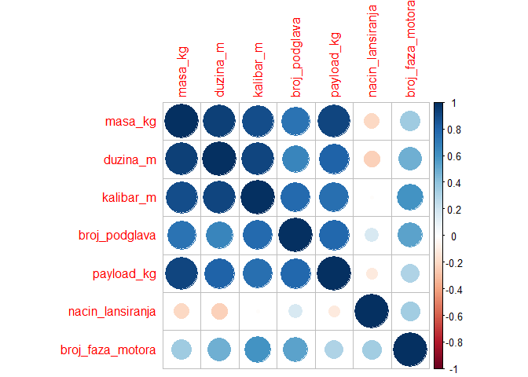

```r
library(corrplot)

corrplot(cor(rakete3[ ,-6]))
```

Podaci su u velikoj meri korelisani.

```r
kmeans_model = kmeans(rakete3, centers = 2, nstart = 10)
kmeans_model$cluster
```

```
##  1  2  3  4  5  6  7  8  9 10 11 12 13 14 15 17 18 20 22 23 24 27 28 29 34 35
##  1  1  2  2  2  2  2  2  2  2  2  1  2  2  2  2  2  2  2  2  2  2  2  2  2  1
## 36 38 39
##  2  2  2
```

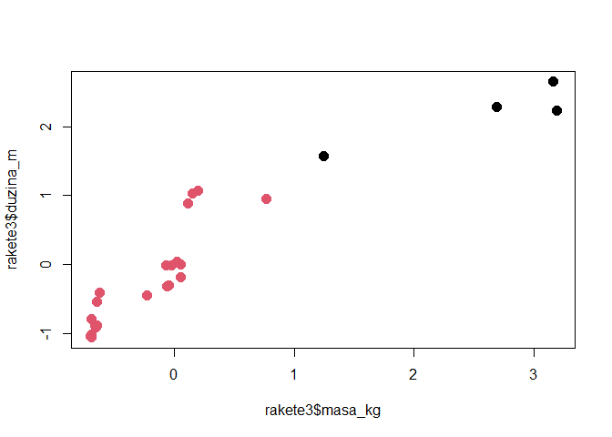

```r
klasteri = kmeans_model$cluster
plot(rakete3$masa_kg, rakete3$duzina_m, pch = 16, cex = 1.5, col = klasteri)
```

#### Vizualizacija

```r
library("mclust")
mcl_model = Mclust(rakete3,2)

class(mcl_model)
```

```
## [1] "Mclust"
```

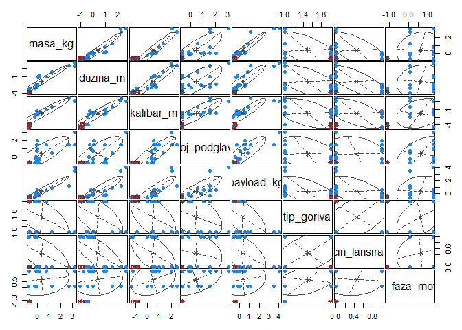

```r
plot(mcl_model, what = "classification")
```

```r
library(ggplot2)

klaster = as.factor(kmeans_model$cluster)
```

Na ovom pairs plot-u sa elipsama klastera su prikazani odnosi svaka dva prediktora u smislu klastera kojem pripadaju.

Ako se na nekoj slici primećuje dijagonalan položaj tačaka, to može značiti da su prediktori jako korelisani.

Ova pojava se primećuje kod prediktora “masa_kg” i “duzina_m”, kao i kod promenljivih “masa_kg” i “payload_kg”

```r
cor(rakete$masa_kg, rakete$duzina_m)
```

```
## [1] 0.9230398
```

```r
cor(rakete$masa_kg, rakete$payload_kg)
```

```
## [1] 0.9132365
```

Vidimo da je korelacija znantno visoka u oba slučaja.

Kako su jako korelisana obeležja “masa_kg” i “payload_kg”, predstavimo to grafički implementacijom ggplot-a.

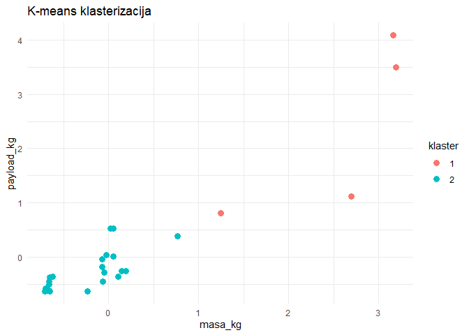

```r
ggplot(rakete3, aes(x = masa_kg, y = payload_kg , color = klaster)) +
  geom_point(size = 3) +
  ggtitle("K-means klasterizacija") +
  theme_minimal()
```

I ovaj grafik ima smisla, što je veća masa, to je i vrednost payload-a veća, što implicira da su vrednosti raspoređene pretežno dijagonalno, ukazivajući na jaku korelisanost ova dva prediktora.

#### Zašto možemo zaključiti da je ova podela baš po dometu?

Postoji više odgovora na ovu temu.

Pored dometa koji na jedan način opisuju neku raketu iz baze, postoje i drugi atributi kao što su masa, dužina, veličina, vrsta goriva, način lansiranja, itd. Sve one su indirektno povezane sa dometom. Pretpostavlja se da ako raketa ima veće dimenzije i težinu da će imati i duži domet i obrnuto. Može se zaključiti da algoritam K-means uspešno razdvoja rakete po tipu domena, iako nema nikakve informacije o dometu pre, jer koristi sličnosti među karakteristikama koje su povezane sa dometom.

## Šesti zadatak

Glavni razlog zašto ne postoji mnogo ruskih raketa srednjeg dometa je zbog Sporazuma o nuklearnim snagama srednjeg dometa (INF) koji je potpisan 1987. godine, pred kraj Hladnog rata, od strane američkog predsednika Ronalda Regana i sovjetskog lidera Mihaila Gorbačova. Ovaj sporazum je zabranio proizvodnju raketa sa dometom između 500 i 5500 kilometara, što se klasifikuje u rakete srednjeg dometa.

Zbog toga su sovjetske snage morale uništiti pretežno sve rakete srednjeg domena, pa su se zato kasnije fokusirale na stvaranje raketa kratkog i dugog dometa.

Sve je to trajalo do kraja oktobra 2018. godine, kada je tadašnji američki predsednik, Donald Trump, doneo odluku o povlačenju SAD iz tog sporazuma, optužujući Rusiju da su prekršili ugovor. Ovaj potez je omogućio Rusiji da obnovi razvoj raketa srednjeg domena.

Sporan je bio sastanak američkog savetnika za bezbednost, Džona Boltona, i ruskog ministra odbrane, Sergeja Šojgua, 2018. godine gde je razgovarano o nesuglasicama vezanim za INF sporazum. Rusija tvrdi da je SAD prekršila ugovor, a ne oni.

Za sve to vreme, Kina nije bila ograničena bilo kakvim ugovor, tako da su oni razvijali rakete srednjeg dometa što im je omogućilo da se pretvore u ozbiljnu vojnu i ekonomsku silu.